# GymTrainingPredict.rmd

Richie Liew

18 Feb 2017

## Background

Using devices such as Jawbone Up, Nike FuelBand, and Fitbit it is now possible to collect a large amount of data about personal activity relatively inexpensively. These type of devices are part of the quantified self movement â a group of enthusiasts who take measurements about themselves regularly to improve their health, to find patterns in their behavior, or because they are tech geeks. One thing that people regularly do is quantify how much of a particular activity they do, but they rarely quantify how well they do it. In this project, your goal will be to use data from accelerometers on the belt, forearm, arm, and dumbell of 6 participants. They were asked to perform barbell lifts correctly and incorrectly in 5 different ways. More information is available from the website here: http://groupware.les.inf.puc-rio.br/har (see the section on the Weight Lifting Exercise Dataset).

## Data

The training data for this project are available here: https://d396qusza40orc.cloudfront.net/predmachlearn/pml-training.csv

The test data are available here: https://d396qusza40orc.cloudfront.net/predmachlearn/pml-testing.csv

## Understanding and Studying the Data

Set working directory

```r
setwd("C:/Users/LIEWR/Desktop/rproject/08_Practical_Machine_Learning")
```

# Read in training data set

Read in both training and testing data sets from given sites

```r
GymTrainData <- read.csv("./data/pml-training.csv")
GymTestData <- read.csv("./data/pml-testing.csv")
```

# Reduce the length of the variable names associated

This is very important for fast and acurate results

```r
attach(GymTrainData)
```

# View a summary of the Classe field data

Take a look at the summary of the dataset

```r
table(GymTrainData$classe)
```

```
##
##    A    B    C    D    E
## 5580 3797 3422 3216 3607
```

# List 33 headings of the data set

Get a rough view of the columns headers

```r
head(names(GymTrainData),33)
```

```
##  [1] "X"                    "user_name"            "raw_timestamp_part_1"
##  [4] "raw_timestamp_part_2" "cvtd_timestamp"       "new_window"
##  [7] "num_window"           "roll_belt"            "pitch_belt"
## [10] "yaw_belt"             "total_accel_belt"     "kurtosis_roll_belt"
## [13] "kurtosis_picth_belt"  "kurtosis_yaw_belt"    "skewness_roll_belt"
## [16] "skewness_roll_belt.1" "skewness_yaw_belt"    "max_roll_belt"
## [19] "max_picth_belt"       "max_yaw_belt"         "min_roll_belt"
## [22] "min_pitch_belt"       "min_yaw_belt"         "amplitude_roll_belt"
## [25] "amplitude_pitch_belt" "amplitude_yaw_belt"   "var_total_accel_belt"
## [28] "avg_roll_belt"        "stddev_roll_belt"     "var_roll_belt"
## [31] "avg_pitch_belt"       "stddev_pitch_belt"    "var_pitch_belt"
```

# View some data in Historgram

View a few groupings to get a little understanding of the data

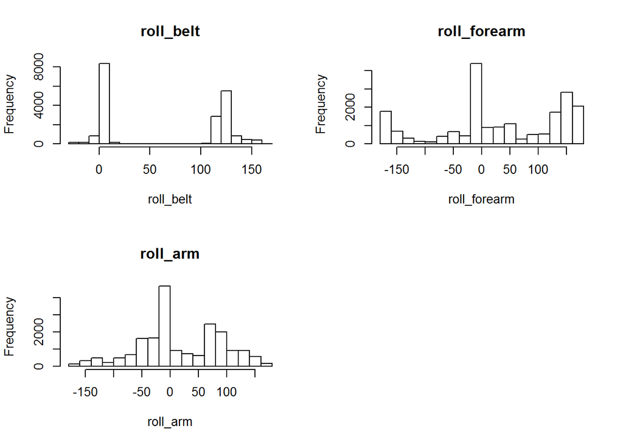

```r
par(mfrow=c(2,2))
hist(roll_belt, main = "roll_belt")
hist(roll_forearm, main = "roll_forearm")
hist(roll_arm, main = "roll_arm")
```

## Cleaning and manipulating the Data

### Find out which columns are in Factors

```r
ColumnNames <- c()
nCounts = ncol(GymTrainData) - 1
for(i in 1:nCounts)
{
  if(is.factor(GymTrainData[,i]))
  {
    ColumnNames <- c(ColumnNames, i)
  }
}
```

### Removed all Factor Columns

This will removed factors columns

```r
GymTrainData <- GymTrainData[,-ColumnNames]
```

```r
GymTrainData <- GymTrainData[,-c(1,2,3,4,5,6,7)]
```

### Removed all ‘NA’

Remove all ‘NA’ as this does not work in Random Forest algorithm

```r
GymTrainData <- GymTrainData[, colSums(is.na(GymTrainData)) == 0]
```

# Using Random Forest to Classify

# Load Random Forest Library

Loading Random Forest Library and Caret Library

```r
library(randomForest)
library(caret)
```

# Cross Validation

Cross validation with random sampling and random Forest Algorithm.

```r
SeedNum <- 12333
acc2 <- c()
for(i in 1:5)
{
  set.seed(SeedNum)
  SeedNum <- SeedNum+1
  TrainIndex <- createDataPartition(y=GymTrainData$classe, p=0.75, list=FALSE)
  GymTrainSet <- GymTrainData[TrainIndex,]
  GymTestSet <- GymTrainData[-TrainIndex,]
  # Fit in Random Forest Model
  fit <- randomForest(classe ~., data = GymTrainSet, importance = T)
  # Prediction
  prediction <- predict(fit, GymTestSet)
  GymTestSet$rightPred <- prediction == GymTestSet$classe
  t <- table(prediction, GymTestSet$classe)
  print(t)
  # Accuracies
  acc1 <- sum(GymTestSet$rightPred)/nrow(GymTestSet)
  acc2 <- c(acc2, acc1)
  print(acc1)
}
```

```
##
## prediction    A    B    C    D    E
##          A 1394    5    0    0    0
##          B    1  943   11    0    0
##          C    0    1  843   22    0
##          D    0    0    1  781    2
##          E    0    0    0    1  899
## [1] 0.9910277
##
## prediction    A    B    C    D    E
##          A 1391    7    0    0    0
##          B    2  939    5    0    0
##          C    0    3  849   23    4
##          D    0    0    0  781    6
##          E    2    0    1    0  891
## [1] 0.9891925
##
## prediction    A    B    C    D    E
##          A 1394    7    0    0    0
##          B    1  939    4    0    1
##          C    0    3  850   14    1
##          D    0    0    1  787    2
##          E    0    0    0    3  897
## [1] 0.9924551
##
## prediction    A    B    C    D    E
##          A 1393   12    0    0    0
##          B    2  935    4    0    0
##          C    0    2  851   25    0
##          D    0    0    0  778    0
##          E    0    0    0    1  901
## [1] 0.9906199
##
## prediction    A    B    C    D    E
##          A 1395    2    0    0    0
##          B    0  943    9    0    0
##          C    0    4  845   20    1
##          D    0    0    1  783    1
##          E    0    0    0    1  899
## [1] 0.9920473
```

Mean accuracy is 0.9910685.

```r
mean(acc2)
```

```
## [1] 0.9910685
```

### Classification table

View the classification table

```r
table(prediction, GymTestSet$classe)
```

```
##
## prediction    A    B    C    D    E
##          A 1395    2    0    0    0
##          B    0  943    9    0    0
##          C    0    4  845   20    1
##          D    0    0    1  783    1
##          E    0    0    0    1  899
```

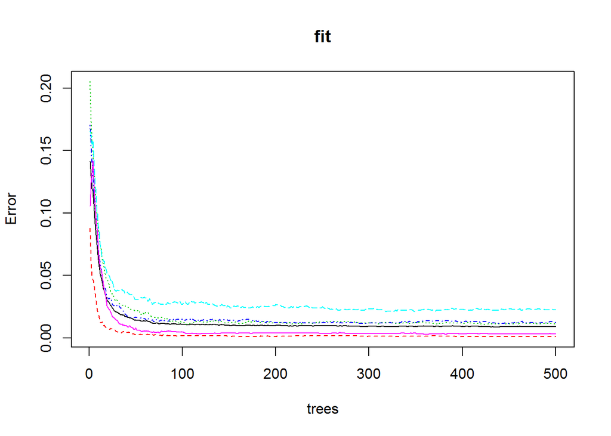

```r
plot(fit)
```

### Examine the importance of each attribute within the fitted classifier

```r
importance(fit)
```

```
##                             A        B        C        D        E
## total_accel_belt     17.64574 21.83902 19.22222 20.40037 18.60943
## gyros_belt_x         16.12170 19.00556 23.50897 15.91242 22.72485
## gyros_belt_y         12.66100 17.74953 18.22481 18.52709 23.44829
## gyros_belt_z         23.18562 34.44690 29.74735 29.51864 33.45319
## accel_belt_x         16.43928 22.15193 21.48283 18.26944 18.06061
## accel_belt_y         15.10141 19.61472 16.21851 18.95794 17.28999
## accel_belt_z         26.85421 33.22730 31.43056 30.56954 26.28323
## magnet_belt_x        24.13333 32.76677 33.40305 25.33358 32.42196
## magnet_belt_y        25.25797 29.92532 30.38691 32.08068 26.33132
## magnet_belt_z        26.27082 30.41453 26.84190 35.12305 26.82319
## roll_arm             29.11359 37.39472 34.67182 39.23037 31.85509
## pitch_arm            20.86608 28.95938 26.15777 25.58445 19.80858
## yaw_arm              24.14705 31.98217 29.29120 29.91441 26.72281
## total_accel_arm      11.46528 25.75730 23.02127 22.58960 24.96122
## gyros_arm_x          19.45275 30.14231 26.11000 28.73051 27.29510
## gyros_arm_y          25.12430 32.75616 29.89665 31.08694 29.01721
## gyros_arm_z          13.78953 22.39798 17.42760 15.34107 16.85173
## accel_arm_x          16.35029 18.76075 19.79659 23.23187 17.52859
## accel_arm_y          21.83759 26.99339 20.99283 24.14167 25.51500
## accel_arm_z          14.30412 25.39476 24.43337 24.59387 24.67271
## magnet_arm_x         18.89135 19.04866 21.79127 20.76259 17.75736
## magnet_arm_y         15.73835 19.90876 20.80384 23.37935 17.81682
## magnet_arm_z         24.17036 28.34740 25.36744 25.61134 24.84624
## roll_dumbbell        26.29034 29.63048 32.58887 34.52130 30.93237
## pitch_dumbbell       14.23310 23.70111 20.40090 15.44954 17.37436
## yaw_dumbbell         19.57474 30.32410 28.76760 26.50906 28.32284
## total_accel_dumbbell 22.49219 28.26055 23.42665 25.93692 27.21868
## gyros_dumbbell_x     23.68937 30.20006 26.78748 24.04961 25.06737
## gyros_dumbbell_y     23.95515 24.46509 30.04351 23.80821 20.57317
## gyros_dumbbell_z     21.47210 28.75200 22.59694 20.94737 20.80297
## accel_dumbbell_x     20.16298 27.71910 26.55345 22.98757 24.92588
## accel_dumbbell_y     30.53972 33.23589 33.58073 32.20017 35.06053
## accel_dumbbell_z     23.99536 32.44270 31.31628 30.37932 34.40354
## magnet_dumbbell_x    27.26772 30.16971 34.07384 31.12985 25.96274
## magnet_dumbbell_y    37.82638 38.51584 50.49058 37.81473 35.20410
## magnet_dumbbell_z    54.29115 50.91260 61.10552 49.97953 44.05170
## roll_forearm         34.58851 30.68336 39.09560 30.32326 29.26079
## pitch_forearm        34.03908 35.23075 37.54498 39.70809 34.89330
## yaw_forearm          20.10530 27.51412 22.16099 23.85811 25.17020
```

[output cut: 45 more lines]

```
## magnet_dumbbell_y                45.74300        572.73081
## magnet_dumbbell_z                65.37275        673.46580
## roll_forearm                     36.35476        515.68409
## pitch_forearm                    42.76713        641.66311
## yaw_forearm                      31.05820        160.84649
## total_accel_forearm              30.61219        100.18380
## gyros_forearm_x                  33.81969         81.67556
## gyros_forearm_y                  41.57656        129.73535
## gyros_forearm_z                  40.31817         86.13762
## accel_forearm_x                  28.31503        273.57296
## accel_forearm_y                  33.70958        137.48256
## accel_forearm_z                  37.41346        221.95292
## magnet_forearm_x                 26.31595        200.33210
## magnet_forearm_y                 31.59946        210.36818
## magnet_forearm_z                 40.22005        254.02434
```

## Obtain the plot of variable importance

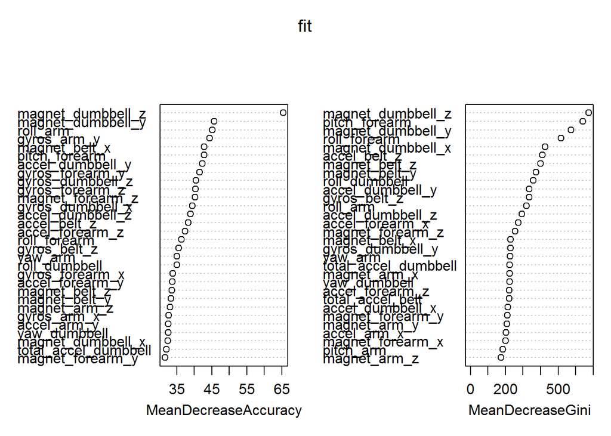

```r
varImpPlot(fit)
```

## Applying the Random Forest into 20 Test Cases

```r
fit <- randomForest(classe ~., data = GymTrainData)
nrow(GymTestData)
```

```
## [1] 20
```

```r
prediction <- predict(fit, GymTestData)
prediction
```

```
##  1  2  3  4  5  6  7  8  9 10 11 12 13 14 15 16 17 18 19 20
##  B  A  B  A  A  E  D  B  A  A  B  C  B  A  E  E  A  B  B  B
## Levels: A B C D E
```